# Funciones compuestas

Expliquemoslo mediante el proceso de hacer un pastel, primero tenemos que pensar en hacer la base:

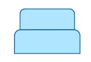

Después añadimos la cobertura

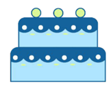

Retomando el caso de las funciones. El proceso de composición de funciones es bastante similar. Lo podemos ver como una maquina que realiza procesos, pueden ser procesos algebraicos u otros, pero algún tipo de procesamiento le van a realizar a la variable independiente:

- Tenemos nuestra variable $x$ que la vamos a ingresar a una función $g(x)$ y entonces sale ya procesada.
- Lo que salga de $g(x)$ va a ingresar a una segunda función, en este caso $f(x)$.
- El resultado final es la composición de funciones $f \circ g$.

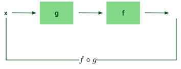

Pero también tenemos la definición formal siguiente.

## Definición

Conocidas las funciones $f(x)$ y $g(x)$, la composición de
$f(x)$ y $g(x)$ está dada por: $$f\circ g=(f\circ g)(x)=f(g(x))$$

```python
#Importando librerías y ajustando Latex
import matplotlib.pyplot as plt
import numpy as np

#Configurando Latex
# Configuración de Matplotlib para usar LaTeX
plt.rcParams.update({
    "text.usetex": True,
    "font.family": "serif",
    "font.serif": ["Computer Modern Roman"],
    "text.latex.preamble": r"\usepackage{amsmath}"
})
```

Veamos como componer 2 funciones.  
Pero primero declaremos nuestra variable independiente $x$ y su resolución de $1000$ puntos.

```python
N = 1000 #Resolución de la variable
x=np.linspace(-10,10,N)
```

Primero, obtengamos nuestra primera función $g(x)$, la elección será una $parábola$ con ecuación $g(x)=x^2$, además grafiquemosla en un intervalo $-10 \leq x \leq 10$.

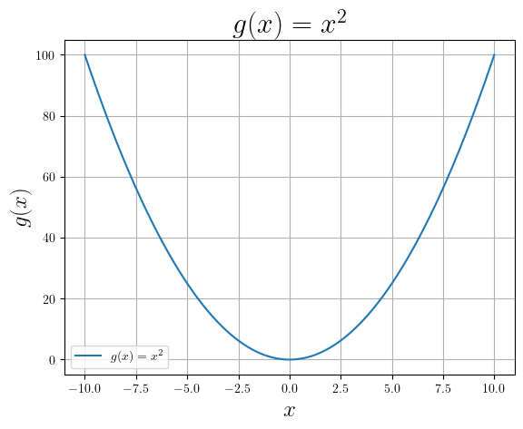

```python
#Definiendo una función de parabola
#Este será mi g(x)
def g(x):
    return x**2
y = g(x)
fig, ax = plt.subplots()
ax.plot(x,y,label=r'$g(x) = x^2$')

plt.title(r'$g(x) =x^2 $',fontsize=23)
plt.xlabel(r'$x$',fontsize=18)
plt.ylabel(r'$g(x)$',fontsize=18)
plt.grid()
plt.legend()
plt.show()
```

Ahora definiremos nuestra segunda función $f(x)$, esta será una función $seno(x)$, entonces $f(x)=seno(x)$, además la graficaremos en un intervalo de $-10\leq x \leq 10$.

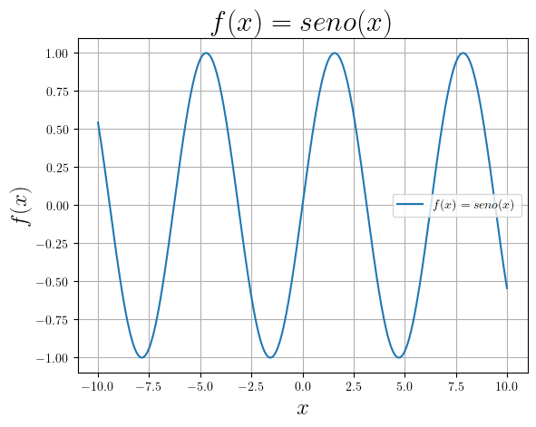

```python
#Definiendo una función seno(x)
#Este será mi f(x)
def f(x):
    return np.sin(x)

y2 = f(x)
fig, ax = plt.subplots()
ax.plot(x,y2,label=r'$f(x) = seno(x)$')

plt.title(r'$f(x)= seno(x) $',fontsize=23)
plt.xlabel(r'$x$',fontsize=18)
plt.ylabel(r'$f(x)$',fontsize=18)
plt.grid()
plt.legend()
plt.show()
```

Ahora hagamos el proceso de composición de funciones $$f \circ g$$ Es decir:

1. Evaluamos $g(x)$
2. La salida de $g(x)$ la evaluamos en $f(x)$
3. Graficamos la función

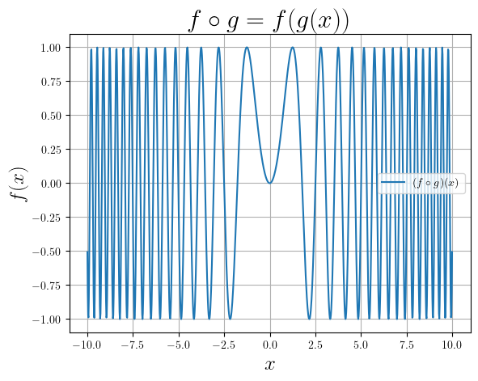

```python
#Composición de funciones
#Directamente
f_o_g = f(g(x))

#Graficando
fig, ax = plt.subplots()
ax.plot(x,f_o_g,label=r'$(f\circ g)(x)$')
plt.title(r'$f\circ g = f(g(x)) $',fontsize=23)
plt.xlabel(r'$x$',fontsize=18)
plt.ylabel(r'$f(x)$',fontsize=18)
plt.grid()
plt.legend()
plt.show()
```

Recuerda:
En la función que se encuentra hasta la *derecha* de $$f\circ g = (f\circ g)(x) =f(g(x))$$ es la que lleva la $x$ o la que se evalua **primero** y la función de hasta la *izquierda*, es la que **recibe la salida de la primera evaluación de $x$**.